# Using R

## Learning objectives

**By the end of this lesson, you should be able to:**

- Navigate Rstudio
- Run code from console notebook
- Perform mathematical operations in R
- Assign variables
- Describe different data types
- Use functions
- Import data into R

This semester, we will be using R to perform data manipulation, analysis, and visualization

## Introduction

### What is R?

R is a free, open source computing *software* used for statistical analysis and graphing. R is also a computing *language*. This means that R software interprets the R language, which is a specific set of vocabulary, formatting, and structure, to perform specific tasks. Other coding languages are Java, C++, python, etc.

### What is Rstudio?

Rstudio is an interface that runs the R software in a user friendly format. Rstudio allows the user to run R code, take notes, view graphs, and view files in one window.

We will be using Rstudio in class for computing assignments. When you open Rstudio, you should see three main panes.

- The *console* is where the R code is run
- The *environment* shows you varables that have been created in R. You can also click to see history or code run in this pane.
- The *viewer* has tabs to display plots, files on your computer, and help documentation.

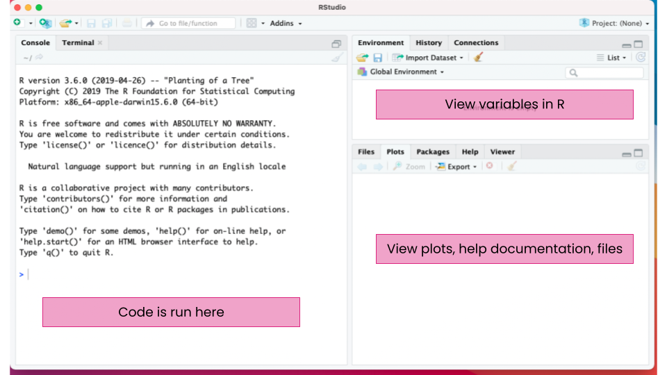

Rstudio

## File management

Before we start coding, it is important to set up a folder where you will be working this semester so that everything is organized and R knows where to find your files. In Rstudio, you can set up an *R project* which is a folder on your computer. When you open the project, Rstudio will automatically go to that folder, making it easier to work with data (importing and exporting) and create coding scripts.

You will make an R project for the class work. When you open Rstudio it will automatically open the last project. Or you can open by using File –> Open Project.

### Tips for naming files and directories

A large part of coding is moving through directories (folders) and accessing files.

When naming files and directories, it is important that they will be easy to work with.

- R is case sensitive! So be aware of your capitalization
- Do *not* use spaces in your names. If you would like to separrate words you can use “_” or “-”
- Pay attention to file extensions (i.e. .jpg, .pdf, .txt). You will need to use full name when working with files.
- Folders in names are separated by “/”. So for example the directory “Documents/bio_files” is a folder “bio_files” inside the folder “Documents.” “Documents/bio_files/photosynthesis.pdf” Is a PDF file inside the bio_files folder.

**Exercise**: Complete the make an R project exercise

## Using R

The next few sections will go through common tasks performed in R, which are needed to complete analyses.

### Mathematical calculations

R can perform basic mathematical calculations. To compute a calculations, simply type it in the *Console*. You can do addition (+), subtraction (-), multiplication (*), division (/), power (^), to name a few. You can also use parentheses as usual in mathematical equations.

For example for 5 times 2:

```r
5 * 2
```

```
## [1] 10
```

One your own, try some mathematical calculations in the Console.

### Using a R script

While you can run code in the console, it is a much better practice to create an R script. This allows you to save your scripts so that you know what you did in an analysis and makes your science *reproducible*. In the script, you can take notes, write code, and run code all from the same file. You can also save the file and re-run or go back and edit later.

Open up a new script by going to File –> New File –> R script. A script file will open above the console.

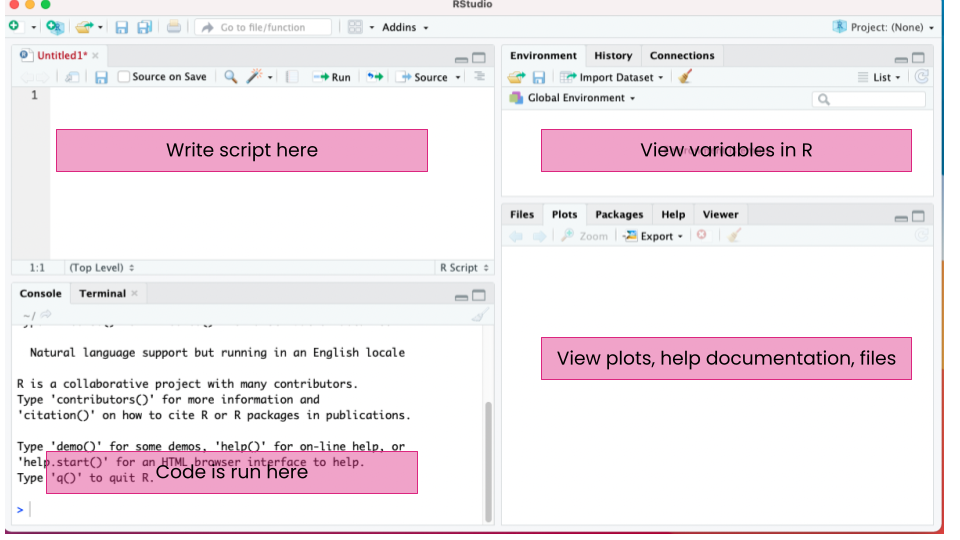

All of your code should be typed in the script. To run the code from the notebook, but your cursor on the line that you want to run. Then click “Ctrl + enter” on a Windows or Linux machine or ‘Cmd + enter’ on a Mac.

To add notes, add a ‘#’ to the beginning of a line. This line will not be run in R. For example:

```r
# I am doing math
5 * 10
```

```
## [1] 50
```

**Exercise** Try out some code in a script. Complete steps one and two of exercise 2.

### Functions in R

Most tasks in R will be accomplished using **functions**. Functions is code that is stored in R and will run a specific task.

Functions are run using the function name followed by the “arguments.” A function can have any number of arguments.

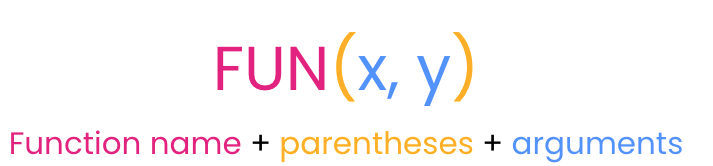

Functions

Functions can range from very simple to very complex. Many functions exist in R without doing anything, you can “load” additional functions through “packages”, or you can even make your own functions.

For example, `log` is a function that will take the natural log of the value given as an argument.

```r
log(1.5)
```

```
## [1] 0.4054651
```

The `log` function can also take an addition argument which sets the base that the logarithms are computed. Two arguments are possible with `log`, x (or the value) and base. So to take the base 10 logarithm of the value 1.5, you could do the following:

```r
log(1.5, 10)
```

```
## [1] 0.1760913
```

This could be written to include the names of the arguments to avoid confusion.

```r
log(x=1.5, base =10)
```

```
## [1] 0.1760913
```

There are many other mathematical function such as sum, max, min, mean, median, sd (standard deviation).

Hint: To get help with a specific function, use ‘?’ followed by the function name

**Exercise** Try out a function in your script. Complete step three exercise 2.

### Assigning variables

In R, you can store information (numbers, tables, text, etc.) in variables. To do this, a variable is assigned a name using the characters `<-`. For example, to assign the letter a the value 1.5, type:

```r
a <- 1.5
```

Then, when you run `a`, you can see the value.

```r
a
```

```
## [1] 1.5
```

You can now treat `a` as 1.5. For example, you can take the log of `a`, which is the same as running `log(1.5)`

```r
log(a)
```

```
## [1] 0.4054651
```

### Data types

So far, we have only dealt with single numbers, but R can handle numbers or text. With numbers, you can type them in regularly and R will recognize them as such. Text is put into quotations (““). You can use single(’) or double (”) in R. Without the quotation mark R will try to find a variable of the same name.

For example, instead of a number, you can store text in a variable:

```r
b <- "hello"
```

Then when your run the varable `b`, you get the text as the output.

```r
b
```

```
## [1] "hello"
```

There are other types of data, but numbers (*numeric*) and text (*characters*) are the two main types we will use in this class.

### Vectors

Data can be stored in different data structures including vectors, data frames, and matrices.

**Vectors** are a one dimensional way to put together data of the *same* type (i.e. all text or all characters). The most common way to create a vectors is by using the `c()` function, which concatenates, or combines, values into a vector.

Here, a vector with the numbers 5, 10, 20 are made into a vector named example.vector

```r
example.vector <- c(5, 10, 20)
example.vector
```

```
## [1]  5 10 20
```

You can also perform mathematical calculations or functions with vectors. The function is performed on each entry in the vector

```r
example.vector / 5
```

```
## [1] 1 2 4
```

Vectors can also store character data.

```r
rainbow_colors <- c('red', 'orange', 'yellow', 'green', 'blue', 'indigo', 'violet')
rainbow_colors
```

```
## [1] "red"    "orange" "yellow" "green"  "blue"   "indigo" "violet"
```

#### Using Functions

You can also run a function with a vector. For example, the function `sum` takes the sum of all numbers.

```r
sum(example.vector)
```

```
## [1] 35
```

You can also use functions on vectors made with characters. For example, here I will use the function `length` to see how long the character vector `rainbow_colors` is.

```r
length(rainbow_colors)
```

```
## [1] 7
```

#### Subsetting vectors

One useful tool is using subsets to determine what is in a specific place in a vector. This is done using brackets “[]”.

In the `rainbow_colors` vector, there are 7 elements. If you want to see what is the third element, you would do the following:

```r
rainbow_colors[3]
```

```
## [1] "yellow"
```

If you want to to see what is in the fourth, fifth, and sixth place, you would use the `c()` function again to use more than one number.

```r
rainbow_colors[c(4, 5, 6)]
```

```
## [1] "green"  "blue"   "indigo"
```

Alternatively, in R you can also use `4:6` to go from *4* to *6*. The `:` symbol creates a sequence.

```r
rainbow_colors[4:6]
```

```
## [1] "green"  "blue"   "indigo"
```

### Data frames

**Data frames** are data structures with rows and columns, like a table. Each column is essentially a vector, so must have the same data type (i.e. numbers or characters). However, a data frame can consists of columns with different data types. This is widely used for storing data because you can have a column with the treatment name (text) and then a column of the measurement (number).

A data frame might look something like this

```
##   treatment growth
## 1   control      5
## 2   control      8
## 3   control      6
## 4    high N      1
## 5    high N      8
## 6    high N      9
## 7     low N      5
## 8     low N      2
## 9     low N      3
```

A **matrix** is similar to a data frame except that *all data* in a matrix are the same type (i.e. all characters or all numbers).

## Working with data frames

Data frames most common data structure that you will be working with. Here, we will go over some of the basics of data frames.

### Creating a data table

For the most part, you will be importing data into R as a data frame from a csv file. However, you can make your own using R functions.

One way to make a data frame to do this is using the function `data.frame()` The arguments are what goes into the data frame *columns*. This data frame will have one column of characters and two columns of numbers. You can also use “=” to name the column.

```r
data.frame(nitrogen = c('low', 'med', 'high'), growth = c(30, 22, 45), height = c(5, 10, 15) )
```

```
##   nitrogen growth height
## 1      low     30      5
## 2      med     22     10
## 3     high     45     15
```

You should also *save* the data frame assigning (`<-`) to a variable.

```r
class_data <- data.frame(nitrogen = c('low', 'med', 'high'), growth = c(30, 22, 45), height = c(5, 10, 15) )
class_data
```

```
##   nitrogen growth height
## 1      low     30      5
## 2      med     22     10
## 3     high     45     15
```

You can also add row or column names or change the existing ones using `rownames` or `colnames`. Let’s say that this data is based on the amount of nitrogen added to plants and I want the row names to include the exact amount (in g). The key to this function is that you must give the same number of elements as there are rows to `rownames` and columns to `colnames`. You are *assigning* the column or row names with new data.

```r
rownames(class_data)
```

```
## [1] "1" "2" "3"
```

```r
rownames(class_data) <- c('N5', 'N10', 'N20')
class_data
```

```
##     nitrogen growth height
## N5       low     30      5
## N10      med     22     10
## N20     high     45     15
```

### Import data

Often data is much bigger than a 3x3 table and is organized in an excel sheet. The main way that you will be adding data to R is using the `read.csv` function. This function takes the file name in quotes as an argument, file. It also has the argument header. This defaults to TRUE. if you have a header you can leave it. If not header should be FALSE. Otherwise the first row of data will be make into the header.

For example, if I have a file “fly_data.csv” in my directory I can load it in an assign it fly as follows:

```r
fly<-read.csv(file = 'fly_data.csv', header = TRUE)
```

```r
head(fly)
```

```
##   species                          site n
## 1  boycei                   Chiricahuas 1
## 2  boycei            Chiricahuas West 3 1
## 3  boycei             Chiricahuas cliff 7
## 4  boycei              Chiricahuas-2078 1
## 5  boycei Iron Creek Campsite, Gila, NM 1
## 6  boycei                   McNarey, AZ 1
```

**Exercise** Import your data from last class exercise

### Subsetting

Just like you did with vectors, you can also show specific rows and columns or *subset* data frames. This is again done with brackets. However, in data frames you specify the number row and columns. The first number in brackets is the row, the second is the column. So if you want the third row in the first column you would use [3, 1]. For example:

```r
class_data[3, 1]
```

```
## [1] "high"
```

Again, you can specify a range using “:”

```r
class_data[1, 2:3]
```

```
##    growth height
## N5     30      5
```

If you would like all rows or all columns, you leave the place in brackets empty.

```r
class_data[2, ]
```

```
##     nitrogen growth height
## N10      med     22     10
```

```r
class_data[ , 1]
```

```
## [1] "low"  "med"  "high"
```

In data frames, you can also specify the column using “$” and the name of the column.

```r
class_data$growth
```

```
## [1] 30 22 45
```

### Functions on data frames

When specify just a single column in the last section, you essentially created a vector. You can also use functions on this vector.

For example, you can use `sum` for total growth

```r
sum(class_data$growth)
```

```
## [1] 97
```

Other useful functions are `max` and `min` which show you the maximum and minimum values.

```r
max(class_data$height)
```

```
## [1] 15
```

## Exercise

### Make an R project

We will use an R project for the class work.

#### On your desktop

1. To make an R project for the class, go to “File –> New Project” in Rstudio.
2. Click on “New Directory.” This is creating a new folder on your computer for the R project.

[figure not shown]

3. Next, you will name the project (remember your tips for naming). You can also specify where the project will be on your computer. For example, I have named by project “BIO231” and put it in my Documents folder.

[figure not shown]

#### In Rstudio cloud

When working in Rstudio cloud, you have to set up a project to begin working.

1. In Rstudio cloud, to start an R project, click New Project then Rstudio project.

[figure not shown]

2. Click at the top to name the project. I used the name BIO231 in the example. You can use whatever you like.

[figure not shown]

3. In Rstudio cloud, you will have to upload any data file that you want to work with instead of accessing it from your computer directly. You can do this in the lower right hand box with the *upload* button

[figure not shown]

Back to lesson

### Create a script

1. Open up a new R script and try running some code.
2. Save the script. This should go in the folder you just created
3. run the `list.files()` function. This shows you the files that in the computer folder that you are working in. *You should see the script you made in the previous step.* If not, something has gone wrong with your script. Double check where it is saved and that you have your R project open.

Back to lesson

### Importing data

1. Add your csv file of the data you collected in the first class to your R project folder.
2. Use `read.csv` to import the data. Don’t forget to assign it a name!

Back to lesson

### Yahtzee exercise

In this exercise you will practice the skills that you just learned: creating variables, working with data frames, mathematical operations, and functions. **Your code should be all run in an R script and submitted to Moodle when your are done.**

1. Play a game of yahtzee!
2. Make a file with your scores and save as a csv. Do not do any of the math!
3. Use `read.csv` to import your data
4. Add row and column names for player names and the score category in R
5. Calculate the scores using R for the teammates. There are many ways to do this. Just find one that works for you. You can create new vectors or data frames to do this.
6. Determine the winner! Use a function here.

## List of functions used today

- `log`
- `c`
- `sum`
- `length`
- `data.frame`
- `rownames` and `colnames`
- `read.csv`
- `head`
- `sum`
- `max` and `min`

## Resources

- [R for Data Science](https://r4ds.hadley.nz/workflow-basics)
- [Data Science in R: A Gentle Introduction](https://bookdown.org/jgscott/DSGI/getting-started-in-r.html)
- [Rstudio projects](https://support.posit.co/hc/en-us/articles/200526207-Using-RStudio-Projects)